# P8451_final_ML

Ruixi Li

2024-03-26

# Research Question

My research question is to generate a hypotheses regarding a wide range of prenatal lifestyles and chemical exposures affect birth outcome(measured by birthweight) using data-driven methods.

# Load .Rdata file and Data Preparation

rexpose package were introduced here in hope of characterization more easily. But it seemed too rigid to be applied to datasets containing both continuous and categorical variables. So I only deal with continuous exposome with this package.

```r
library(rexposome)
args(loadExposome)
```

```
## function (exposures, description, phenotype, description.famCol = "family",
##     exposures.asFactor = 5, warnings = TRUE)
## NULL
```

```r
# Load data using path of where file is stored
load("exposome.RData")

# modify the dataframes to fit with the data format required by package 'rexposome'.
## merge covariates and phenotype, phenotype only has birthweight.
phenotype = phenotype |> select(ID, e3_bw)
cov_phe = inner_join(covariates, phenotype, by = "ID")

## I am planning on exploring the effect of prenatal exposome towards babies' birth weight. So I just removed all postnatal exposure.


### tailor exposome into all continuous prenatal exposome, corresponding with codebook
pre = codebook |> filter(period == "Pregnancy")
name = rownames(pre)
pre_exp = exposome |> select(ID,any_of(name))
pre_exp_cont = pre_exp |> select(where(is.numeric))
filtered_name = colnames(pre_exp_cont)
### tailor the codebook(description containing all prenatal exposome description info, including family-each row is an exposure)
exp_description <- codebook |>  filter(variable_name %in% filtered_name)
### Since codebook's row name was originally the exposure names, I just removed the 'variable name' column
exp_description <- exp_description[,-1]
### let ID be pre_exp's rowname and remove the id column
rownames(pre_exp) <- pre_exp_cont[,1]
pre_exp_cont <- pre_exp_cont[,-1]
### let ID be cov_phe's rowname and remove the id column
rownames(cov_phe) <- cov_phe[,1]
cov_phe <- cov_phe[,-1]


# get the object fit with rexposome
exp <- loadExposome(
    exposures = pre_exp_cont,
    description = exp_description,
    phenotype = cov_phe
)
# give an overall look at the exposome of interest
skimr::skim(pre_exp)
```

Data summary

| Name | pre_exp |
| --- | --- |
| Number of rows | 1301 |
| Number of columns | 89 |
| _______________________ |  |
| Column type frequency: |  |
| factor | 16 |
| numeric | 73 |
| ________________________ |  |
| Group variables | None |

**Variable type: factor**

| skim_variable | n_missing | complete_rate | ordered | n_unique | top_counts |
| --- | --- | --- | --- | --- | --- |
| e3_alcpreg_yn_None | 0 | 1 | FALSE | 2 | 0: 896, 1: 405 |
| h_cereal_preg_Ter | 0 | 1 | FALSE | 3 | (0,: 531, (9,: 459, (27: 311 |
| h_dairy_preg_Ter | 0 | 1 | FALSE | 3 | (27: 651, (17: 380, (0,: 270 |
| h_fastfood_preg_Ter | 0 | 1 | FALSE | 3 | (0.: 672, (0.: 535, (0,: 94 |
| h_fish_preg_Ter | 0 | 1 | FALSE | 3 | (1.: 490, (4.: 468, (0,: 343 |
| h_folic_t1_None | 0 | 1 | FALSE | 2 | 1: 695, 0: 606 |
| h_fruit_preg_Ter | 0 | 1 | FALSE | 3 | (0.: 922, (18: 373, (0,: 6 |
| h_legume_preg_Ter | 0 | 1 | FALSE | 3 | (2,: 787, (0.: 269, (0,: 245 |
| h_meat_preg_Ter | 0 | 1 | FALSE | 3 | (10: 487, (0,: 427, (6.: 387 |
| h_pamod_t3_None | 0 | 1 | FALSE | 4 | Ver: 594, Oft: 474, Som: 191, Non: 42 |
| h_pavig_t3_None | 0 | 1 | FALSE | 3 | Low: 952, Med: 302, Hig: 47 |
| h_veg_preg_Ter | 0 | 1 | FALSE | 3 | (0,: 539, (8.: 470, (16: 292 |
| hs_tl_mdich_None | 0 | 1 | FALSE | 2 | Und: 1284, Det: 17 |
| h_blueyn300_preg_None | 0 | 1 | FALSE | 2 | 0: 1194, 1: 107 |
| h_greenyn300_preg_None | 0 | 1 | FALSE | 2 | 1: 980, 0: 321 |
| hs_cotinine_mcat_None | 0 | 1 | FALSE | 3 | Non: 759, Smo: 385, SHS: 157 |

**Variable type: numeric**

| skim_variable | n_missing | complete_rate | mean | sd | p0 | p25 | p50 | p75 | p100 | hist |
| --- | --- | --- | --- | --- | --- | --- | --- | --- | --- | --- |
| ID | 0 | 1 | 651.00 | 375.71 | 1.00 | 326.00 | 651.00 | 976.00 | 1301.00 | ▇▇▇▇▇ |
| h_abs_ratio_preg_Log | 0 | 1 | 0.39 | 0.40 | -0.48 | 0.10 | 0.30 | 0.73 | 1.71 | ▂▇▅▃▁ |
| h_no2_ratio_preg_Log | 0 | 1 | 3.00 | 0.47 | 2.10 | 2.67 | 2.96 | 3.30 | 4.52 | ▅▇▆▂▁ |
| h_pm10_ratio_preg_None | 0 | 1 | 23.50 | 7.94 | 8.07 | 17.54 | 23.02 | 27.68 | 47.70 | ▃▇▅▃▁ |
| h_pm25_ratio_preg_None | 0 | 1 | 15.03 | 2.70 | 6.96 | 13.29 | 14.88 | 17.00 | 22.24 | ▁▃▇▅▁ |
| h_accesslines300_preg_dic0 | 0 | 1 | 0.20 | 0.40 | 0.00 | 0.00 | 0.00 | 0.00 | 1.00 | ▇▁▁▁▂ |
| h_accesspoints300_preg_Log | 0 | 1 | 2.67 | 0.82 | 1.27 | 1.96 | 2.88 | 3.35 | 4.53 | ▅▆▇▇▁ |
| h_builtdens300_preg_Sqrt | 0 | 1 | 417.06 | 143.48 | 11.02 | 340.04 | 401.49 | 502.97 | 807.57 | ▁▃▇▃▁ |
| h_connind300_preg_Sqrt | 0 | 1 | 12.74 | 4.67 | 1.89 | 9.98 | 12.93 | 15.90 | 27.28 | ▂▆▇▂▁ |
| h_fdensity300_preg_Log | 0 | 1 | 11.61 | 1.30 | 10.26 | 10.26 | 11.36 | 12.83 | 15.60 | ▇▃▅▂▁ |
| h_frichness300_preg_None | 0 | 1 | 0.07 | 0.08 | 0.00 | 0.00 | 0.04 | 0.12 | 0.42 | ▇▃▁▁▁ |
| h_landuseshan300_preg_None | 0 | 1 | 0.42 | 0.13 | 0.00 | 0.34 | 0.42 | 0.51 | 1.00 | ▁▆▇▁▁ |
| h_popdens_preg_Sqrt | 0 | 1 | 77.02 | 44.62 | 0.00 | 53.79 | 74.98 | 96.21 | 261.50 | ▃▇▂▁▁ |
| h_walkability_mean_preg_None | 0 | 1 | 0.27 | 0.07 | 0.10 | 0.20 | 0.25 | 0.32 | 0.62 | ▅▇▅▁▁ |
| hs_as_m_Log2 | 0 | 1 | -3.01 | 5.72 | -38.62 | -5.42 | -1.93 | 1.01 | 6.49 | ▁▁▁▇▇ |
| hs_cd_m_Log2 | 0 | 1 | -2.18 | 0.91 | -7.84 | -2.67 | -2.43 | -1.71 | 4.80 | ▁▂▇▁▁ |
| hs_co_m_Log2 | 0 | 1 | -1.69 | 1.19 | -5.18 | -2.51 | -2.01 | -0.55 | 2.50 | ▁▇▅▆▁ |
| hs_cs_m_Log2 | 0 | 1 | 0.48 | 0.57 | -1.16 | 0.07 | 0.40 | 0.81 | 3.45 | ▁▇▃▁▁ |
| hs_cu_m_Log2 | 0 | 1 | 10.40 | 0.26 | 9.04 | 10.25 | 10.44 | 10.54 | 11.17 | ▁▁▃▇▁ |
| hs_hg_m_Log2 | 0 | 1 | 0.57 | 1.40 | -9.02 | -0.31 | 0.58 | 1.57 | 5.44 | ▁▁▂▇▁ |
| hs_mn_m_Log2 | 0 | 1 | 3.54 | 0.47 | 1.66 | 3.29 | 3.57 | 3.81 | 5.45 | ▁▂▇▂▁ |
| hs_mo_m_Log2 | 0 | 1 | -0.69 | 0.59 | -2.72 | -0.98 | -0.73 | -0.40 | 6.13 | ▅▇▁▁▁ |
| hs_pb_m_Log2 | 0 | 1 | 3.21 | 0.70 | 1.22 | 2.62 | 3.19 | 3.81 | 7.55 | ▂▇▃▁▁ |
| h_humidity_preg_None | 0 | 1 | 76.56 | 9.87 | 55.83 | 70.63 | 77.10 | 86.54 | 90.67 | ▃▂▆▅▇ |
| h_pressure_preg_None | 0 | 1 | 991.51 | 13.22 | 974.90 | 980.84 | 983.45 | 1002.32 | 1015.49 | ▇▁▁▅▂ |
| h_temperature_preg_None | 0 | 1 | 11.20 | 4.47 | 3.12 | 8.13 | 10.16 | 13.80 | 22.57 | ▂▇▃▂▂ |
| h_ndvi100_preg_None | 0 | 1 | 0.39 | 0.16 | 0.11 | 0.25 | 0.41 | 0.52 | 0.74 | ▇▆▇▇▂ |
| h_lden_cat_preg_None | 0 | 1 | 57.47 | 7.81 | 33.92 | 50.00 | 58.63 | 64.36 | 77.40 | ▁▆▇▇▁ |
| hs_dde_madj_Log2 | 0 | 1 | 5.84 | 1.87 | 0.86 | 4.46 | 5.57 | 7.00 | 10.89 | ▁▇▇▅▂ |
| hs_ddt_madj_Log2 | 0 | 1 | 0.87 | 2.43 | -14.14 | -0.26 | 0.68 | 1.51 | 6.56 | ▁▁▁▇▂ |
| hs_hcb_madj_Log2 | 0 | 1 | 2.95 | 1.27 | -9.42 | 2.32 | 2.80 | 3.49 | 7.36 | ▁▁▁▇▂ |
| hs_pcb118_madj_Log2 | 0 | 1 | 1.25 | 0.97 | -1.17 | 0.63 | 1.05 | 1.83 | 7.43 | ▃▇▂▁▁ |
| hs_pcb138_madj_Log2 | 0 | 1 | 2.87 | 1.36 | -10.19 | 1.79 | 2.92 | 3.79 | 8.21 | ▁▁▁▇▁ |
| hs_pcb153_madj_Log2 | 0 | 1 | 3.89 | 1.17 | 1.11 | 2.85 | 3.85 | 4.74 | 9.84 | ▅▇▅▁▁ |
| hs_pcb170_madj_Log2 | 0 | 1 | 1.09 | 1.70 | -2.04 | -0.32 | 0.87 | 2.20 | 7.78 | ▆▇▅▂▁ |
| hs_pcb180_madj_Log2 | 0 | 1 | 2.95 | 1.61 | -10.12 | 2.07 | 2.99 | 4.03 | 9.35 | ▁▁▂▇▁ |
| hs_sumPCBs5_madj_Log2 | 0 | 1 | 4.86 | 1.30 | 2.30 | 4.01 | 4.71 | 5.74 | 9.34 | ▃▇▅▂▁ |
| hs_dep_madj_Log2 | 0 | 1 | 1.70 | 1.59 | -13.41 | 0.99 | 1.66 | 2.67 | 7.59 | ▁▁▁▇▁ |
| hs_detp_madj_Log2 | 0 | 1 | -1.57 | 4.03 | -28.38 | -3.93 | -0.53 | 1.01 | 5.47 | ▁▁▁▅▇ |
| hs_dmp_madj_Log2 | 0 | 1 | 2.24 | 2.91 | -17.14 | 2.01 | 2.80 | 3.76 | 8.33 | ▁▁▁▇▅ |
| hs_dmtp_madj_Log2 | 0 | 1 | 1.61 | 3.15 | -15.33 | 1.07 | 2.23 | 3.49 | 7.78 | ▁▁▂▇▅ |
| hs_pbde153_madj_Log2 | 0 | 1 | -1.74 | 2.85 | -15.00 | -1.88 | -0.95 | -0.03 | 6.43 | ▁▁▁▇▁ |
| hs_pbde47_madj_Log2 | 0 | 1 | -0.78 | 1.42 | -11.58 | -1.76 | -0.97 | 0.12 | 5.12 | ▁▁▃▇▁ |
| hs_pfhxs_m_Log2 | 0 | 1 | -0.98 | 1.43 | -17.83 | -1.73 | -0.93 | -0.16 | 3.76 | ▁▁▁▇▅ |
| hs_pfna_m_Log2 | 0 | 1 | -0.75 | 1.36 | -10.75 | -1.31 | -0.59 | 0.09 | 2.56 | ▁▁▁▇▅ |
| hs_pfoa_m_Log2 | 0 | 1 | 1.05 | 1.04 | -5.48 | 0.41 | 1.20 | 1.74 | 4.98 | ▁▁▅▇▁ |
| hs_pfos_m_Log2 | 0 | 1 | 2.56 | 1.12 | -1.82 | 1.96 | 2.65 | 3.21 | 5.58 | ▁▂▇▇▂ |
| hs_pfunda_m_Log2 | 0 | 1 | -2.66 | 1.50 | -26.21 | -3.21 | -2.48 | -1.71 | -0.04 | ▁▁▁▁▇ |
| hs_bpa_madj_Log2 | 0 | 1 | 1.47 | 1.71 | -11.02 | 0.29 | 1.15 | 2.34 | 6.74 | ▁▁▁▇▂ |
| hs_bupa_madj_Log2 | 0 | 1 | 1.02 | 3.46 | -15.58 | -1.34 | 1.42 | 3.60 | 8.53 | ▁▁▅▇▃ |
| hs_etpa_madj_Log2 | 0 | 1 | 3.33 | 3.58 | -12.12 | 1.24 | 3.28 | 5.13 | 12.73 | ▁▁▆▇▁ |
| hs_mepa_madj_Log2 | 0 | 1 | 7.30 | 2.37 | -0.31 | 5.88 | 7.72 | 8.62 | 15.26 | ▁▃▇▃▁ |
| hs_oxbe_madj_Log2 | 0 | 1 | 3.03 | 3.14 | -10.51 | 0.76 | 2.55 | 4.78 | 13.65 | ▁▂▇▅▁ |
| hs_prpa_madj_Log2 | 0 | 1 | 5.23 | 3.18 | -14.15 | 3.75 | 5.77 | 7.07 | 13.61 | ▁▁▂▇▂ |
| hs_trcs_madj_Log2 | 0 | 1 | 3.43 | 3.44 | -4.81 | 0.55 | 2.66 | 6.59 | 10.69 | ▁▇▇▅▅ |
| hs_mbzp_madj_Log2 | 0 | 1 | 2.98 | 1.60 | -3.74 | 1.86 | 2.89 | 4.10 | 9.30 | ▁▂▇▃▁ |
| hs_mecpp_madj_Log2 | 0 | 1 | 5.03 | 0.98 | 2.43 | 4.33 | 4.85 | 5.63 | 10.41 | ▂▇▃▁▁ |
| hs_mehhp_madj_Log2 | 0 | 1 | 4.16 | 1.25 | -0.46 | 3.46 | 4.07 | 4.79 | 9.92 | ▁▅▇▁▁ |
| hs_mehp_madj_Log2 | 0 | 1 | 2.94 | 1.43 | -7.47 | 1.79 | 3.06 | 3.81 | 8.70 | ▁▁▅▇▁ |
| hs_meohp_madj_Log2 | 0 | 1 | 3.78 | 1.22 | -0.02 | 3.10 | 3.68 | 4.42 | 9.61 | ▁▇▆▁▁ |
| hs_mep_madj_Log2 | 0 | 1 | 7.77 | 1.82 | 3.29 | 6.40 | 7.78 | 8.91 | 14.11 | ▂▇▇▃▁ |
| hs_mibp_madj_Log2 | 0 | 1 | 5.31 | 1.05 | 0.93 | 4.59 | 5.34 | 5.92 | 9.46 | ▁▂▇▂▁ |
| hs_mnbp_madj_Log2 | 0 | 1 | 4.96 | 1.21 | -0.71 | 4.20 | 4.86 | 5.57 | 12.65 | ▁▆▇▁▁ |
| hs_ohminp_madj_Log2 | 0 | 1 | -0.30 | 1.53 | -11.46 | -0.72 | -0.21 | 0.27 | 6.06 | ▁▁▁▇▁ |
| hs_oxominp_madj_Log2 | 0 | 1 | -0.06 | 1.59 | -11.55 | -0.70 | -0.02 | 0.52 | 5.55 | ▁▁▁▇▁ |
| hs_sumDEHP_madj_Log2 | 0 | 1 | 6.01 | 1.08 | 3.21 | 5.23 | 5.88 | 6.70 | 11.69 | ▂▇▃▁▁ |
| e3_asmokcigd_p_None | 0 | 1 | 0.49 | 1.76 | 0.00 | 0.00 | 0.00 | 0.00 | 15.24 | ▇▁▁▁▁ |
| h_distinvnear1_preg_Log | 0 | 1 | -3.15 | 1.61 | -10.02 | -3.98 | -3.00 | -2.26 | 2.79 | ▁▁▇▃▁ |
| h_trafload_preg_pow1over3 | 0 | 1 | 75.54 | 60.16 | 0.35 | 33.65 | 66.61 | 113.08 | 294.27 | ▇▆▃▁▁ |
| h_trafnear_preg_pow1over3 | 0 | 1 | 14.99 | 8.23 | 0.00 | 7.94 | 12.12 | 21.40 | 39.32 | ▁▇▃▂▁ |
| h_bro_preg_Log | 0 | 1 | 1.26 | 2.30 | -2.98 | -0.50 | 1.87 | 2.75 | 4.90 | ▃▆▁▇▃ |
| h_clf_preg_Log | 0 | 1 | 0.96 | 2.94 | -6.91 | -0.50 | 2.08 | 3.18 | 3.83 | ▁▁▂▃▇ |
| h_thm_preg_Log | 0 | 1 | 2.71 | 1.59 | -1.60 | 1.85 | 2.91 | 3.84 | 5.03 | ▁▂▃▅▇ |

# Data Exploration

## 1. Covariates and phenotypes

1. Since this dataset is a combine data from 6 cohorts, I would explore population characteristics(covariates) and outcomes(phenotypes) by cohorts.

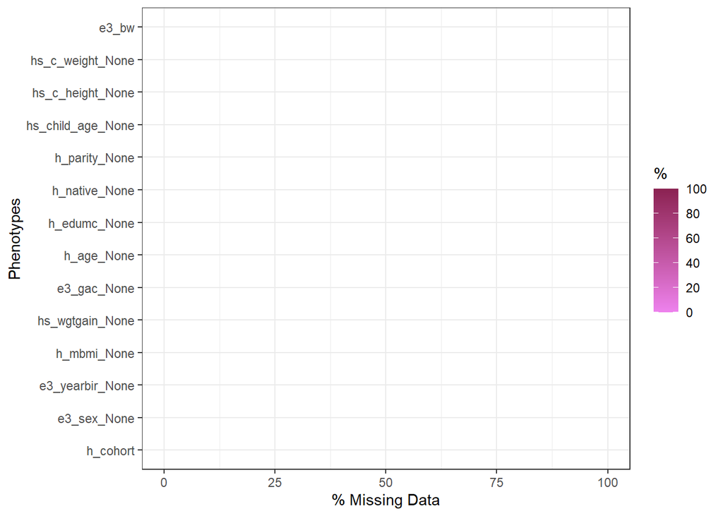

```r
plotMissings(exp, set = "phenotypes")
```

```r
#tableMissings(exp, set = "phenotypes", output = "n")
```

### categorical variables

```r
cate_cov_phe = cov_phe |> select(where(is.factor))

# Frequency table
frequency_tables_cov_phe <- cate_cov_phe %>% map(~ as.data.frame(table(.x)))
frequency_tables_cov_phe |>knitr::kable()# name of variables in these freq tables are displayed in the plot below
```

| .x | Freq |
| --- | --- |
| 1 | 202 |
| 2 | 198 |
| 3 | 224 |
| 4 | 207 |
| 5 | 272 |
| 6 | 198 |

| .x | Freq |
| --- | --- |
| female | 608 |
| male | 693 |

| .x | Freq |
| --- | --- |
| 2003 | 55 |
| 2004 | 107 |
| 2005 | 241 |
| 2006 | 256 |
| 2007 | 250 |
| 2008 | 379 |
| 2009 | 13 |

| .x | Freq |
| --- | --- |
| 1 | 178 |
| 2 | 449 |
| 3 | 674 |

| .x | Freq |
| --- | --- |
| 0 | 146 |
| 1 | 67 |
| 2 | 1088 |

| .x | Freq |
| --- | --- |
| 0 | 601 |
| 1 | 464 |
| 2 | 236 |

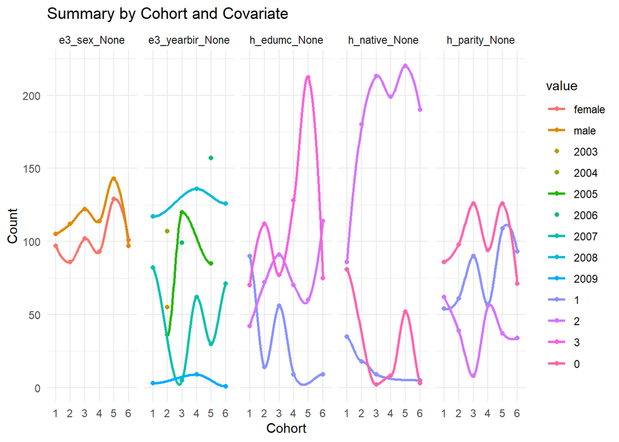

```r
# Difference by cohort
cate_cov_phe_summ = cate_cov_phe %>%
  pivot_longer(cols = -h_cohort, names_to = "covariate", values_to = "value") %>%
  group_by(h_cohort, covariate,value) %>%
  summarize(n = n(), .groups = 'drop') %>%
  ungroup()

cate_cov_phe_summ %>%
  ggplot(aes(x = h_cohort, y = n, color = value)) +
  geom_point() +
  geom_smooth(aes(group=value), method = "loess", se = FALSE) +
  facet_grid(. ~ covariate) +
  theme_minimal() +  # For a cleaner look
  labs(x = "Cohort", y = "Count", title = "Summary by Cohort and Covariate")
```

### continuous variables

```r
cont_cov_phe = cov_phe|> select(where(is.numeric))

summary_table_cov_phe <- cont_cov_phe %>%
  summarise(across(where(is.numeric), list(
    Mean = ~mean(.x, na.rm = TRUE),
    SD = ~sd(.x, na.rm = TRUE),
    Median = ~median(.x, na.rm = TRUE),
    IQR = ~IQR(.x, na.rm = TRUE)
  ))) |>
  pivot_longer(
    cols = everything(),
    names_to = c(".value", "Statistic"),
    names_pattern = "(.*)_(.*)"
  )
summary_table_cov_phe|> knitr::kable()
```

| Statistic | h_mbmi_None | hs_wgtgain_None | e3_gac_None | h_age_None | hs_child_age_None | hs_c_height_None | hs_c_weight_None | e3_bw |
| --- | --- | --- | --- | --- | --- | --- | --- | --- |
| Mean | 25.030708 | 13.504842 | 39.625673 | 30.795058 | 7.975708 | 1.2914643 | 28.517218 | 3389.3021 |
| SD | 5.183072 | 6.240749 | 1.708398 | 4.857010 | 1.612297 | 0.1050532 | 7.689055 | 509.9945 |
| Median | 24.023809 | 12.000000 | 40.000000 | 31.000000 | 8.032854 | 1.2800000 | 26.900000 | 3398.0000 |
| IQR | 6.077137 | 9.000000 | 2.000000 | 6.418957 | 2.420032 | 0.1560000 | 9.800000 | 640.0000 |

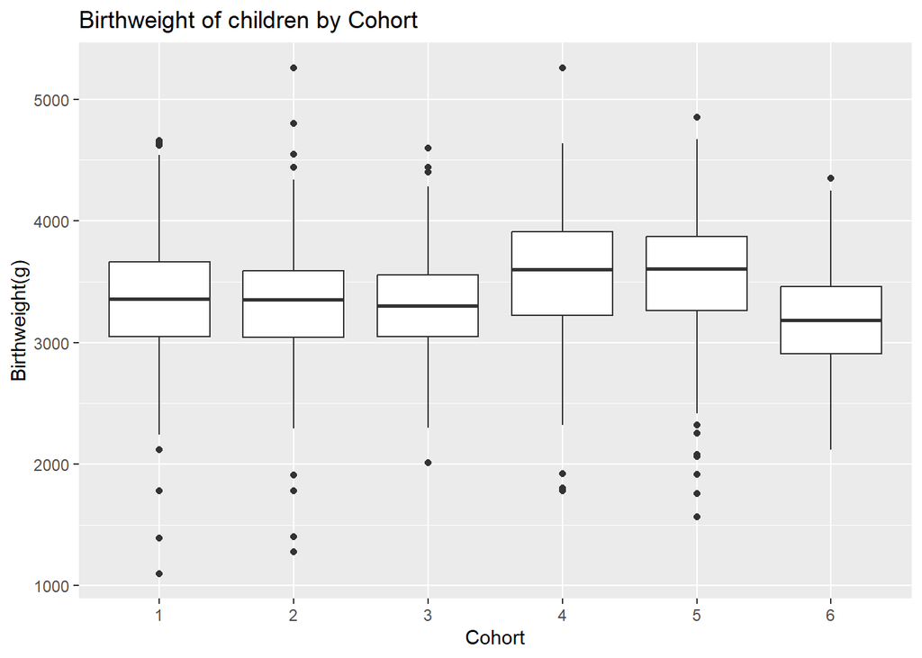

```r
# I specify the continuous variables' names in 'name' vector to add h_cohort in this dataset(I want to assess if there's difference between cohorts-especially the exposome)
name_cont_cov_phe = colnames(cont_cov_phe)[-1]
results_cov_phe = cov_phe |> select(h_cohort, any_of(name_cont_cov_phe))

results_summary_cov_phe = results_cov_phe %>%
  group_by(h_cohort) %>%
  summarize(across(where(is.numeric),
                   list(mean = ~mean(.x, na.rm = TRUE),
                        std = ~sd(.x, na.rm = TRUE))))

# Since birthweight is too large(also my outcome), I displayed it separately.
results_cov_phe |> ggplot(aes(x=h_cohort, y=e3_bw)) + geom_boxplot() +
  labs(x = "Cohort", y = "Birthweight(g)", title = "Birthweight of children by Cohort")
```

```r
results_cov_phe_nobw = results_cov_phe |> select(-e3_bw)

# difference across cohorts
results_melted_cov_phe = melt(results_cov_phe_nobw)
```

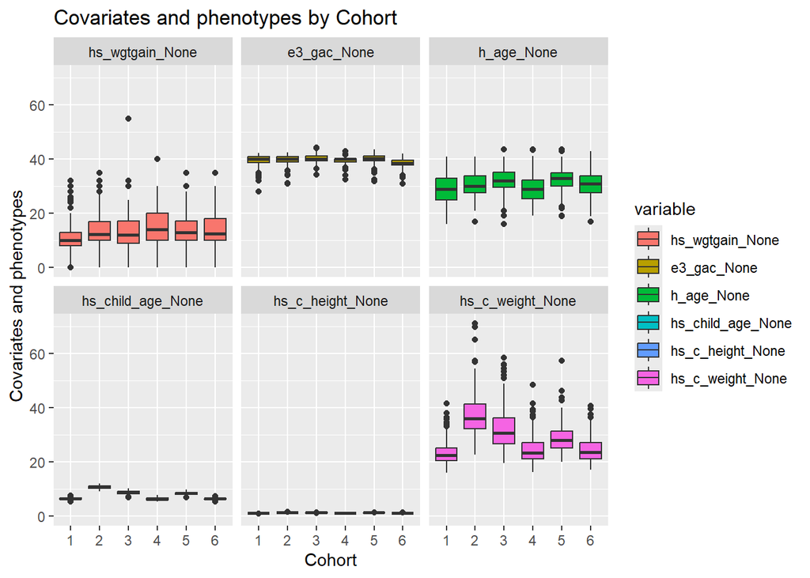

```r
results_melted_cov_phe |>
  ggplot(aes(x=h_cohort, y=value, fill=variable)) + geom_boxplot() + facet_wrap(~variable)+
  labs(x = "Cohort", y = "Covariates and phenotypes", title = "Covariates and phenotypes by Cohort")
```

## 2. Exposome

2. Look at the exposome characteristics by family and the correlation between exposome

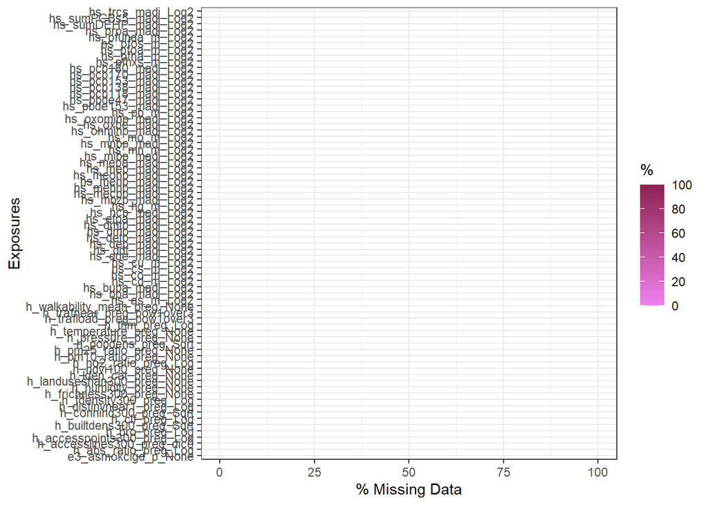

```r
#tableMissings(exp, set = "exposures", output = "n")
plotMissings(exp, set = "exposures")
```

The current exposome data has no missing in the exposures nor in the phenotypes

### continuous

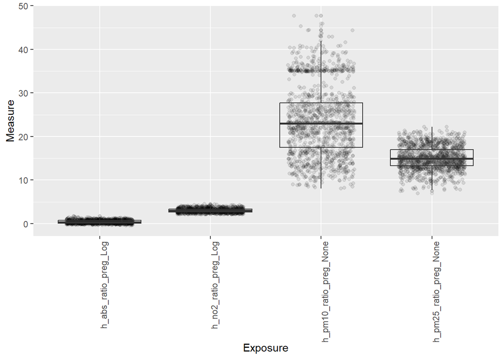

```r
# exposome behavior
# plotFamily(exp, family = "all") generate error message, I don't know why, the for loop didn't work either. it seemed like the 'build environment' had a mixed falimy
plotFamily(exp, family = "Air Pollution")
```

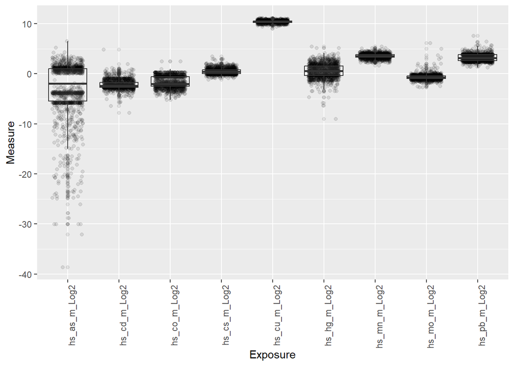

```r
# plotFamily(exp, family = "Built environment")
plotFamily(exp, family = "Metals")
```

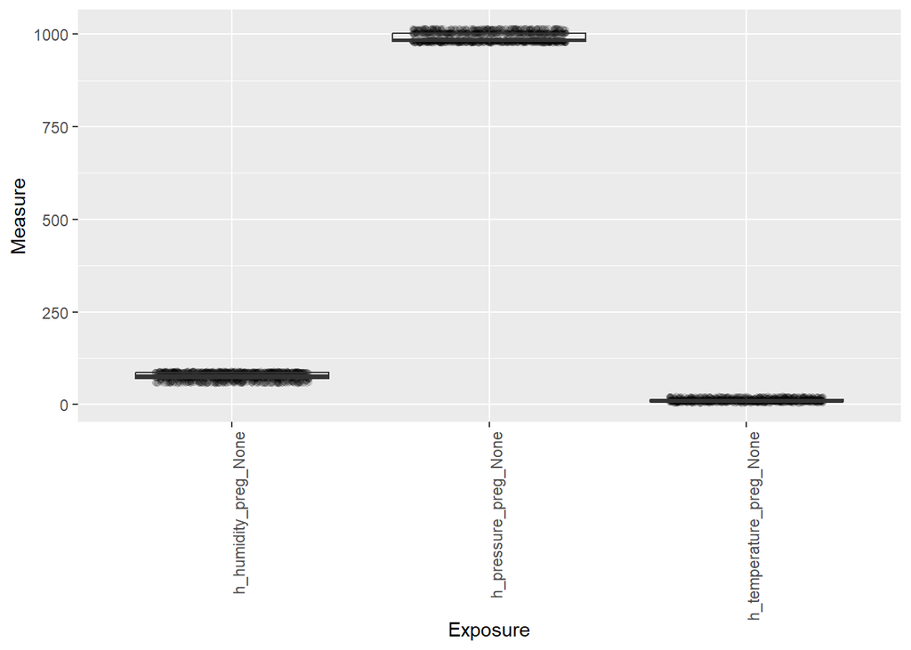

```r
plotFamily(exp, family = "Meteorological")
```

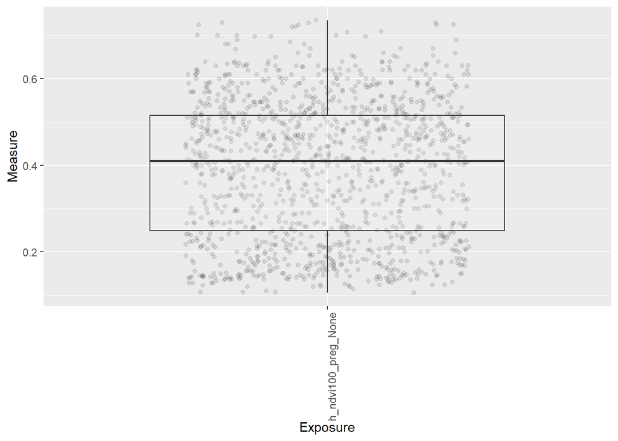

```r
plotFamily(exp, family = "Natural Spaces")
```

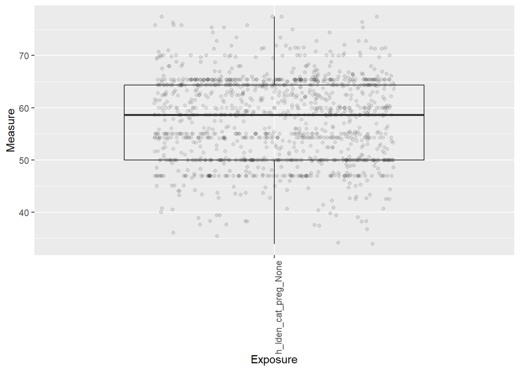

```r
plotFamily(exp, family = "Noise")
```

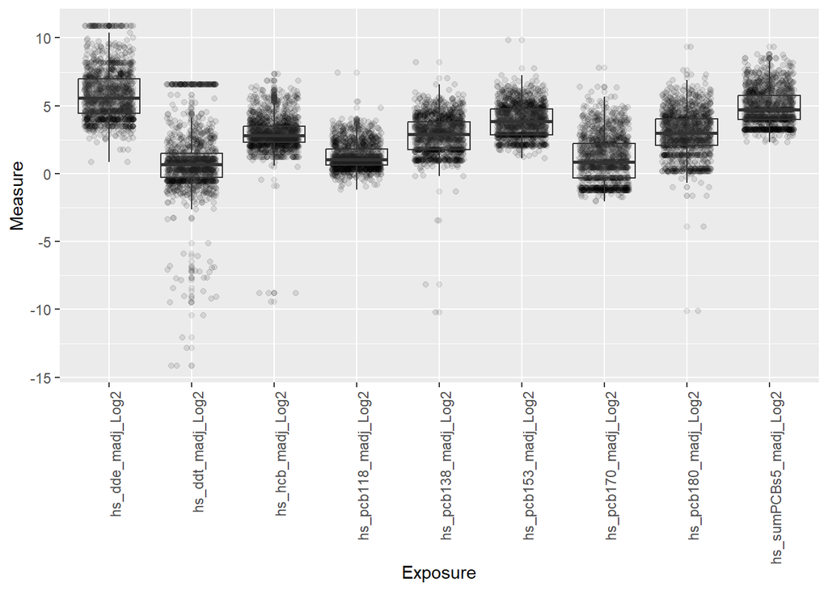

```r
plotFamily(exp, family = "Organochlorines")
```

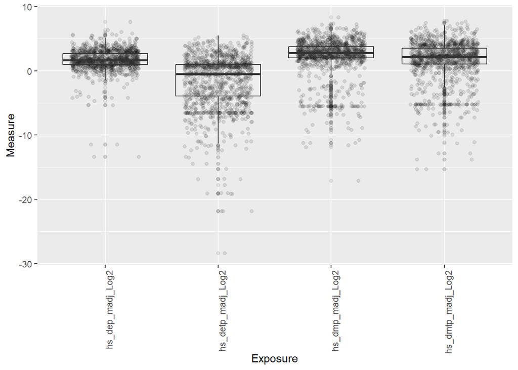

```r
plotFamily(exp, family = "Organophosphate pesticides")
```

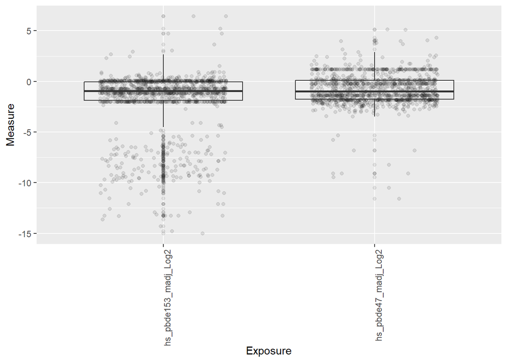

```r
plotFamily(exp, family = "Polybrominated diphenyl ethers (PBDE)")
```

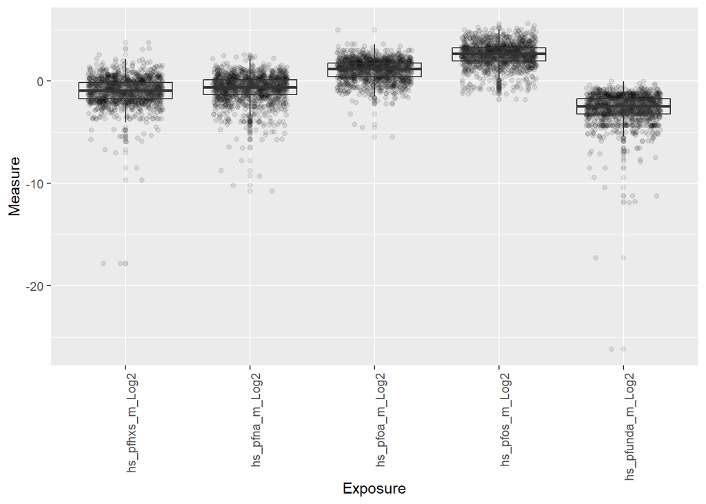

```r
plotFamily(exp, family = "Per- and polyfluoroalkyl substances (PFAS)")
```

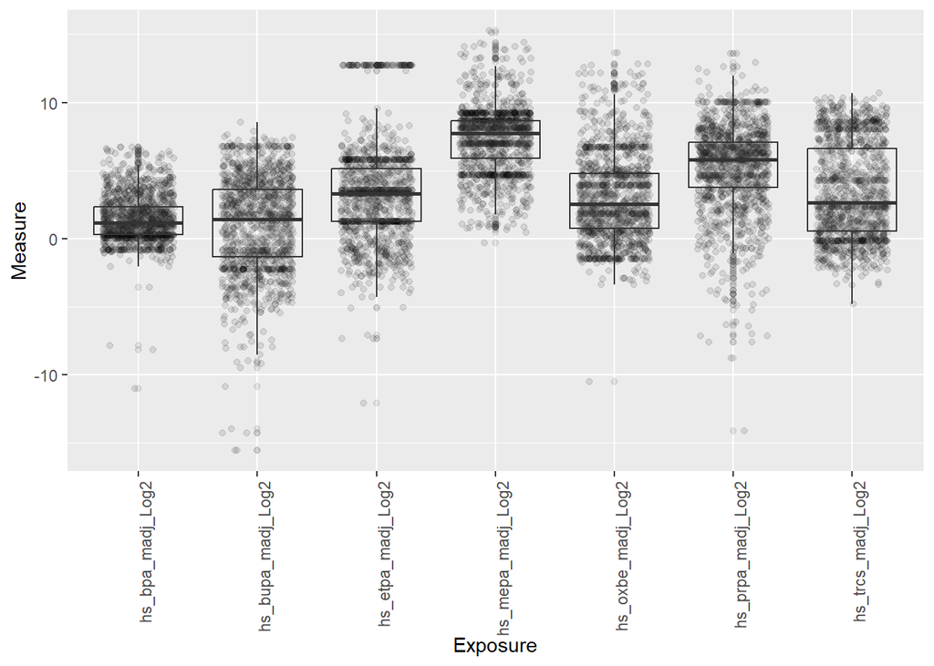

```r
plotFamily(exp, family = "Phenols")
```

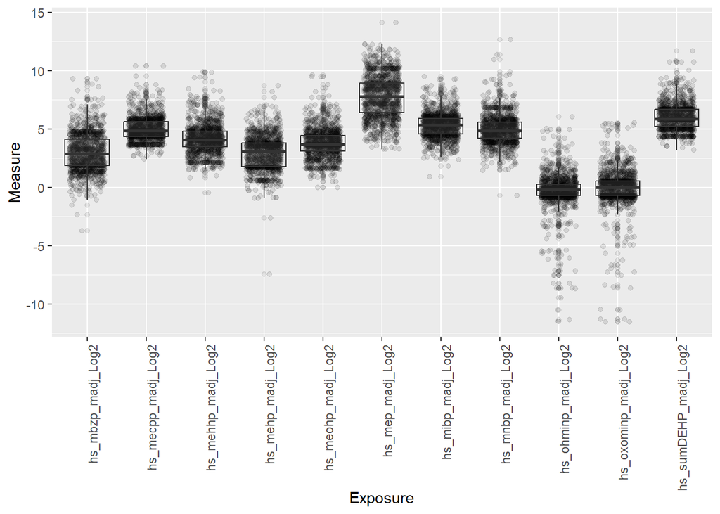

```r
plotFamily(exp, family = "Phthalates")
```

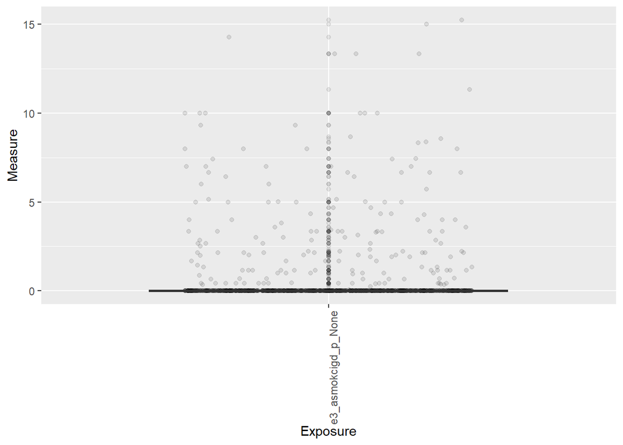

```r
plotFamily(exp, family = "Tobacco Smoke")
```

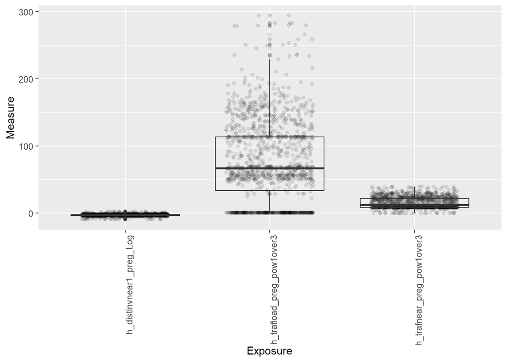

```r
plotFamily(exp, family = "Traffic")
```

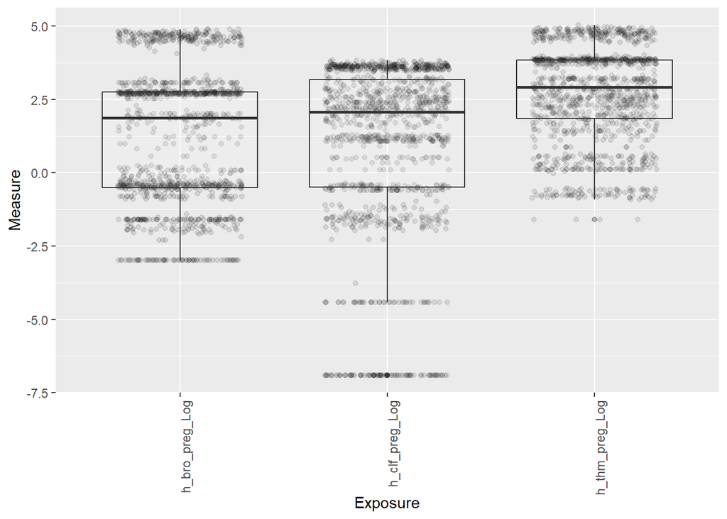

```r
plotFamily(exp, family = "Water DBPs")
```

```r
# exposome are not normally distributed
nm <- normalityTest(exp)
table(nm$normality)
```

```
##
## FALSE
##    71
```

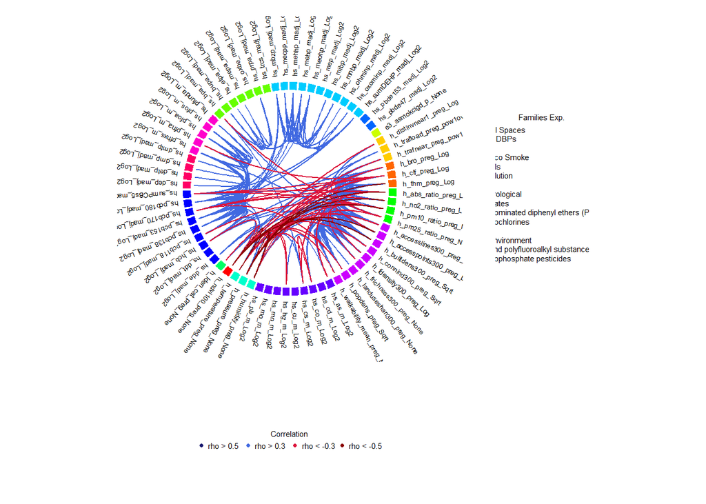

```r
# correlation
exp_cr <- correlation(exp, use = "pairwise.complete.obs", method.cor = "pearson")
plotCorrelation(exp_cr, type = "circos")
```

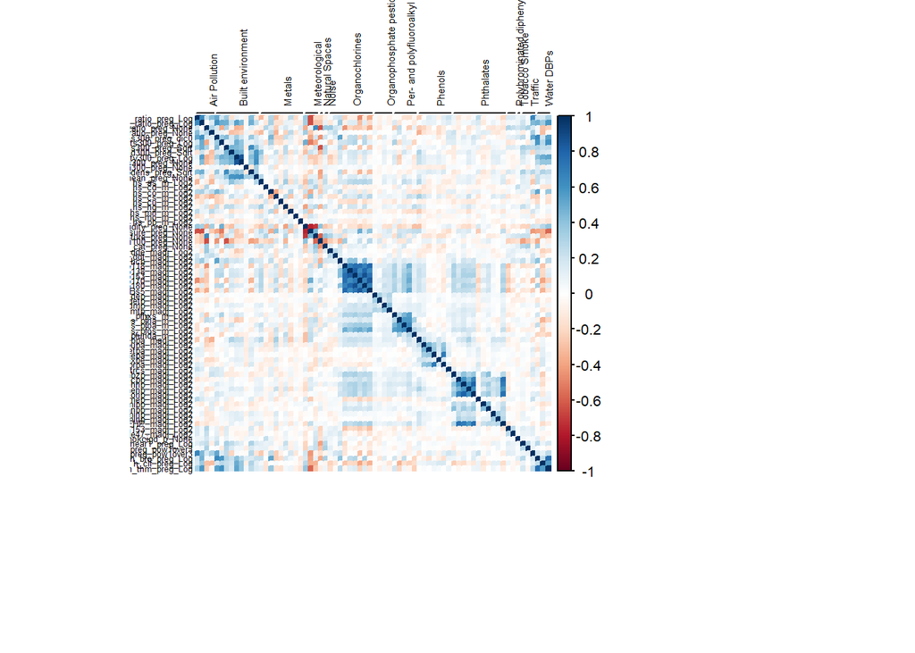

```r
plotCorrelation(exp_cr, type = "matrix")
```